# Pertemuan 3 - Model Distributed Lag, Koyck, dan ARDL

Abdul Rossyid Pratama

2026-09-03

# 1 Pendahuluan

Dokumen ini membahas pemodelan **distributed lag** untuk data penjualan (*sales*) terhadap biaya iklan (*advertising*) selama 40 periode (1975-2014). Beberapa model yang dibandingkan adalah:

- **Model Koyck** — model distributed lag dengan bobot lag menurun secara geometrik
- **Model DLM (Distributed Lag Model)** — dengan orde lag tetap, baik ditentukan manual maupun otomatis
- **Model ARDL (Autoregressive Distributed Lag)** — menggabungkan lag dari variabel dependen dan independen

```r
library(dLagM)
library(dynlm)
library(MLmetrics)
library(lmtest)
library(car)
```

# 2 Data

Data yang digunakan adalah penjualan (Sales) terhadap biaya iklan (Advertising) tahunan dari 1975 sampai 2014.

```r
data <- rio::import("C:/Users/HYPE AMD/Downloads/latihan2_sales_advertising.csv")
str(data)
```

```
## 'data.frame':    40 obs. of  3 variables:
##  $ Year       : int  1975 1976 1977 1978 1979 1980 1981 1982 1983 1984 ...
##  $ Sales      : num  11.7 12 12.3 12.8 13.1 13.6 13.9 14.4 14.7 15.3 ...
##  $ Advertising: num  9.4 9.6 10 10.4 10.8 10.9 11.7 12.2 12.5 12.9 ...
```

Data dibagi menjadi data latih (train, 30 periode pertama) dan data uji (test, 10 periode terakhir), lalu diubah ke format *time series*.

```r
#SPLIT DATA
train<-data[1:30,]
test<-data[31:40,]

#data time series
train.ts<-ts(train)
test.ts<-ts(test)
data.ts<-ts(data)
```

# 3 Model Koyck

Model Koyck mengasumsikan pengaruh variabel independen terhadap dependen menurun secara geometrik seiring bertambahnya lag, sehingga cukup diwakili oleh satu lag dari variabel dependen.

```r
model.koyck <- koyckDlm(x = as.numeric(train$Advertising), y = as.numeric(train$Sales))
summary(model.koyck)
```

```
##
## Call:
## "Y ~ (Intercept) + Y.1 + X.t"
##
## Residuals:
##       Min        1Q    Median        3Q       Max
## -0.265890 -0.120691 -0.005297  0.107270  0.267226
##
## Coefficients:
##             Estimate Std. Error t value Pr(>|t|)
## (Intercept)  1.61369    0.38958   4.142 0.000322 ***
## Y.1          0.74280    0.09797   7.582 4.77e-08 ***
## X.t          0.19436    0.08585   2.264 0.032152 *
## ---
## Signif. codes:  0 '***' 0.001 '**' 0.01 '*' 0.05 '.' 0.1 ' ' 1
##
## Residual standard error: 0.156 on 26 degrees of freedom
## Multiple R-Squared: 0.9954,  Adjusted R-squared: 0.995
## Wald test:  2796 on 2 and 26 DF,  p-value: < 2.2e-16
##
## Diagnostic tests:
## NULL
##
##                             alpha      beta       phi
## Geometric coefficients:  6.274186 0.1943614 0.7428042
```

```r
AIC(model.koyck)
```

```
## [1] -20.60961
```

```r
BIC(model.koyck)
```

```
## [1] -15.14043
```

## 3.1 Peramalan dan Akurasi Model Koyck

```r
fore.koyck <- forecast(model = model.koyck, x = as.numeric(test$Advertising), h = 10)
fore.koyck
```

```
## $forecasts
##  [1] 19.73293 19.94483 20.16054 20.47626 20.71077 20.94328 21.13542 21.39476
##  [9] 21.68459 22.01648
##
## $call
## forecast.koyckDlm(model = model.koyck, x = as.numeric(test$Advertising),
##     h = 10)
##
## attr(,"class")
## [1] "forecast.koyckDlm" "dLagM"
```

```r
mape.koyck <- MAPE(fore.koyck$forecasts, test$Sales)
mape.koyck #data test
```

```
## [1] 0.04712769
```

```r
#akurasi data training
GoF(model.koyck)
```

```
##              n       MAE           MPE        MAPE       sMAPE      MASE
## model.koyck 29 0.1219025 -0.0001551597 0.007579302 0.007579911 0.4213914
##                    MSE     MRAE     GMRAE
## model.koyck 0.02183119 70715208 0.5994542
```

# 4 Model DLM (Distributed Lag Model)

## 4.1 DLM dengan Lag Manual (q = 2)

Model DLM dengan orde lag yang ditentukan secara manual, yaitu q = 2.

```r
model.dlm <- dlm(x = as.numeric(train$Advertising), y = as.numeric(train$Sales), q = 2)
summary(model.dlm)
```

```
##
## Call:
## lm(formula = model.formula, data = design)
##
## Residuals:
##      Min       1Q   Median       3Q      Max
## -0.49181 -0.15731 -0.00976  0.15782  0.48554
##
## Coefficients:
##             Estimate Std. Error t value Pr(>|t|)
## (Intercept)   4.9621     0.3453  14.369 2.76e-13 ***
## x.t           0.1654     0.2362   0.700    0.490
## x.1           0.4118     0.3036   1.356    0.188
## x.2           0.2365     0.2299   1.028    0.314
## ---
## Signif. codes:  0 '***' 0.001 '**' 0.01 '*' 0.05 '.' 0.1 ' ' 1
##
## Residual standard error: 0.2644 on 24 degrees of freedom
## Multiple R-squared:  0.9857, Adjusted R-squared:  0.9839
## F-statistic: 550.5 on 3 and 24 DF,  p-value: < 2.2e-16
##
## AIC and BIC values for the model:
##        AIC     BIC
## 1 10.65158 17.3126
```

```r
AIC(model.dlm)
```

```
## [1] 10.65158
```

```r
BIC(model.dlm)
```

```
## [1] 17.3126
```

## 4.2 Peramalan dan Akurasi DLM (q = 2)

```r
fore.dlm <- forecast(model = model.dlm, x = as.numeric(test$Advertising), h = 10)
fore.dlm
```

```
## $forecasts
##  [1] 20.00000 20.16273 20.34199 20.64514 21.04549 21.28427 21.42434 21.63570
##  [9] 21.98911 22.43611
##
## $call
## forecast.dlm(model = model.dlm, x = as.numeric(test$Advertising),
##     h = 10)
##
## attr(,"class")
## [1] "forecast.dlm" "dLagM"
```

```r
mape.dlm <- MAPE(fore.dlm$forecasts, test$Sales)
mape.dlm
```

```
## [1] 0.06098542
```

```r
#akurasi data training
GoF(model.dlm)
```

```
##            n       MAE          MPE       MAPE      sMAPE      MASE       MSE
## model.dlm 28 0.1974215 -0.000441056 0.01227844 0.01226426 0.6833821 0.0599283
##               MRAE   GMRAE
## model.dlm 24356741 1.03794
```

## 4.3 Penentuan Lag Optimum DLM

Untuk mendapatkan orde lag terbaik, dilakukan pencarian otomatis menggunakan kriteria AIC pada rentang lag 1 sampai 10.

```r
finiteDLMauto(formula = Sales ~ Advertising,
              data = data.frame(train), q.min = 1, q.max = 10,
              model.type = "dlm", error.type = "AIC", trace = TRUE)
```

```
##    q - k    MASE       AIC      BIC   GMRAE    MBRAE R.Adj.Sq    Ljung-Box
## 9      9 0.34922 -12.64945 -0.11518 0.71868 -0.27524  0.98552 0.3688121825
## 10    10 0.35122  -9.22038  3.72414 0.74801  0.01543  0.98048 0.5004571650
## 8      8 0.36932  -7.82507  4.17639 0.60573 -0.47218  0.98440 0.2257284249
## 7      7 0.46948  -0.95390 10.40104 0.97231 -0.34671  0.98142 0.0833971793
## 6      6 0.53634   2.13689 12.73938 0.98902  0.54574  0.98158 0.0129631654
## 5      5 0.59715   4.21576 13.96677 1.25981 -0.65144  0.98222 0.0011054100
## 4      4 0.61259   6.97647 15.78315 1.09895  0.31802  0.98250 0.0011522571
## 3      3 0.64397   7.56299 15.33801 1.10105  0.25684  0.98393 0.0002577476
## 2      2 0.68338  10.65158 17.31260 1.03794 -1.84527  0.98389 0.0001971192
## 1      1 0.75787  12.80053 18.26971 1.20511  0.38642  0.98424 0.0000340988
```

```r
model.dlm2 <- dlm(x = as.numeric(train$Advertising), y = as.numeric(train$Sales), q = 6)
summary(model.dlm2)
```

```
##
## Call:
## lm(formula = model.formula, data = design)
##
## Residuals:
##      Min       1Q   Median       3Q      Max
## -0.23875 -0.14292 -0.00952  0.11967  0.37530
##
## Coefficients:
##             Estimate Std. Error t value Pr(>|t|)
## (Intercept)  6.18860    0.53874  11.487 3.86e-09 ***
## x.t         -0.02885    0.20949  -0.138   0.8922
## x.1          0.46095    0.25488   1.808   0.0894 .
## x.2          0.07351    0.24721   0.297   0.7700
## x.3          0.17767    0.25164   0.706   0.4903
## x.4         -0.11214    0.25382  -0.442   0.6645
## x.5          0.36578    0.25684   1.424   0.1736
## x.6         -0.19025    0.20354  -0.935   0.3638
## ---
## Signif. codes:  0 '***' 0.001 '**' 0.01 '*' 0.05 '.' 0.1 ' ' 1
##
## Residual standard error: 0.213 on 16 degrees of freedom
## Multiple R-squared:  0.9872, Adjusted R-squared:  0.9816
## F-statistic: 176.1 on 7 and 16 DF,  p-value: 6.277e-14
##
## AIC and BIC values for the model:
##        AIC      BIC
## 1 2.136895 12.73938
```

```r
AIC(model.dlm2)
```

```
## [1] 2.136895
```

```r
BIC(model.dlm2)
```

```
## [1] 12.73938
```

## 4.5 Peramalan dan Akurasi DLM (q = 6)

```r
fore.dlm2 <- forecast(model = model.dlm2, x = as.numeric(test$Advertising), h = 10)

#akurasi data test
mape.dlm2 <- MAPE(fore.dlm2$forecasts, test$Sales)
mape.dlm2
```

```
## [1] 0.04718577
```

```r
#akurasi data training
GoF(model.dlm2)
```

```
##             n       MAE           MPE       MAPE       sMAPE      MASE
## model.dlm2 24 0.1445786 -0.0001634197 0.00860594 0.008611496 0.5363401
##                   MSE     MRAE     GMRAE
## model.dlm2 0.03023244 25315789 0.9890186
```

# 5 Model ARDL (Autoregressive Distributed Lag)

Model ARDL menggabungkan lag dari variabel independen (p) dan variabel dependen (q). Berikut dua cara pemanggilan `ardlDlm()` yang menghasilkan model setara: menggunakan argumen `x`/`y` langsung, dan menggunakan notasi `formula`.

```r
model.ardl <- ardlDlm(x = as.numeric(train$Advertising), y = as.numeric(train$Sales), p = 1, q = 1)
summary(model.ardl)
```

```
##
## Time series regression with "ts" data:
## Start = 2, End = 30
##
## Call:
## dynlm(formula = as.formula(model.text), data = data, start = 1)
##
## Residuals:
##       Min        1Q    Median        3Q       Max
## -0.229277 -0.127437  0.009143  0.109228  0.259132
##
## Coefficients:
##             Estimate Std. Error t value Pr(>|t|)
## (Intercept)  1.55786    0.44353   3.512  0.00171 **
## X.t          0.29110    0.13707   2.124  0.04376 *
## X.1         -0.09584    0.16067  -0.596  0.55621
## Y.1          0.74360    0.09964   7.463 8.14e-08 ***
## ---
## Signif. codes:  0 '***' 0.001 '**' 0.01 '*' 0.05 '.' 0.1 ' ' 1
##
## Residual standard error: 0.1576 on 25 degrees of freedom
## Multiple R-squared:  0.9955, Adjusted R-squared:  0.9949
## F-statistic:  1830 on 3 and 25 DF,  p-value: < 2.2e-16
```

```r
AIC(model.ardl)
```

```
## [1] -19.18177
```

```r
BIC(model.ardl)
```

```
## [1] -12.34529
```

```r
model.ardl <- ardlDlm(formula = Sales ~ Advertising,
                      data = train, p = 1, q = 1)
summary(model.ardl)
```

```
##
## Time series regression with "ts" data:
## Start = 2, End = 30
##
## Call:
## dynlm(formula = as.formula(model.text), data = data)
##
## Residuals:
##       Min        1Q    Median        3Q       Max
## -0.229277 -0.127437  0.009143  0.109228  0.259132
##
## Coefficients:
##               Estimate Std. Error t value Pr(>|t|)
## (Intercept)    1.55786    0.44353   3.512  0.00171 **
## Advertising.t  0.29110    0.13707   2.124  0.04376 *
## Advertising.1 -0.09584    0.16067  -0.596  0.55621
## Sales.1        0.74360    0.09964   7.463 8.14e-08 ***
## ---
## Signif. codes:  0 '***' 0.001 '**' 0.01 '*' 0.05 '.' 0.1 ' ' 1
##
## Residual standard error: 0.1576 on 25 degrees of freedom
## Multiple R-squared:  0.9955, Adjusted R-squared:  0.9949
## F-statistic:  1830 on 3 and 25 DF,  p-value: < 2.2e-16
```

```r
AIC(model.ardl)
```

```
## [1] -19.18177
```

```r
BIC(model.ardl)
```

```
## [1] -12.34529
```

## 5.1 Peramalan dan Akurasi ARDL

```r
fore.ardl <- forecast(model = model.ardl, x = as.numeric(test$Advertising), h = 10)
fore.ardl
```

```
## $forecasts
##  [1] 19.72862 19.93768 20.16129 20.53170 20.73047 20.96560 21.14081 21.43616
##  [9] 21.74384 22.09937
##
## $call
## forecast.ardlDlm(model = model.ardl, x = as.numeric(test$Advertising),
##     h = 10)
##
## attr(,"class")
## [1] "forecast.ardlDlm" "dLagM"
```

```r
mape.ardl <- MAPE(fore.ardl$forecasts, test$Sales)
mape.ardl
```

```
## [1] 0.0484832
```

```r
#akurasi data training
GoF(model.ardl)
```

```
##             n       MAE           MPE        MAPE       sMAPE      MASE
## model.ardl 29 0.1238592 -0.0001484019 0.007696613 0.007697173 0.4281553
##                  MSE     MRAE     GMRAE
## model.ardl 0.0214047 81884782 0.7548444
```

## 5.2 Penentuan Lag Optimum ARDL

Pencarian kombinasi orde p (lag X) dan q (lag Y) terbaik dilakukan dengan `ardlBoundOrders()` berdasarkan kriteria AIC.

```r
model.ardl.opt <- ardlBoundOrders(data = data.frame(data), ic = "AIC",
                                  formula = Sales ~ Advertising)
model.ardl.opt
```

```
## $p
##   Advertising
## 1           4
##
## $q
## [1] 15
##
## $Stat.table
##             q = 1      q = 2      q = 3       q = 4        q = 5      q = 6
## p = 1  -15.008746 -11.952031 -11.702811 -10.4556102   -7.4743459 -10.190508
## p = 2  -13.773954 -12.129560 -11.273832  -9.7873186   -6.6233481  -8.740430
## p = 3   -8.848612  -8.848612 -12.443867 -10.3937201   -7.1398397  -9.693082
## p = 4  -12.022451 -10.663941 -10.663941  -8.6692457   -5.3883982  -8.000189
## p = 5   -6.455663  -4.517684  -6.129877  -6.1298773   -5.8218760  -9.506366
## p = 6  -11.513095  -9.679368 -10.603965  -8.7469140   -8.7469140  -8.630625
## p = 7   -5.508868  -3.728014  -6.010216  -4.5325635  -12.0788009 -12.078801
## p = 8   -8.927789  -7.599283  -5.788882  -4.6394213  -11.9646171 -10.910332
## p = 9   -5.602665  -3.769155  -2.219895  -0.2595925   -9.1716507  -7.295497
## p = 10  -9.465550  -7.587108  -5.720971  -3.8196288   -8.1361157  -6.288259
## p = 11   1.701332   2.523049   3.963660   5.8214473   -0.1570961   1.564017
## p = 12  -6.976292  -6.760264  -4.921983  -7.0600636   -9.0408197  -8.605279
## p = 13  -1.534882  -4.200569  -6.944121  -5.0254590  -32.2884029 -46.908793
## p = 14  -3.660390  -1.761109  -2.219038  -3.7538496 -198.9302277         NA
## p = 15 -11.707853 -17.884028 -17.585602          NA           NA         NA
##             q = 7      q = 8        q = 9      q = 10       q = 11     q = 12
## p = 1   -7.624070  -8.686449   -4.7462387 -3.32746110   -2.9869318 -0.9555962
## p = 2   -5.806960  -7.921509   -4.2989938 -2.59233785   -1.1348530  0.3798720
## p = 3   -6.091044  -7.142078   -4.2143900 -1.64141900   -0.2764654  2.0637751
## p = 4   -4.274001  -5.164970   -2.2163924 -0.02517076    0.1775901  3.0432639
## p = 5   -5.454353  -5.301255   -1.9990132  0.94455082    1.2370098  2.5673773
## p = 6   -4.511772  -3.986967   -0.7254173  2.14054832    2.0257425  0.1204914
## p = 7  -13.506180 -11.580354   -7.7220728 -3.84200566   -3.0518769 -4.1223494
## p = 8  -10.910332  -9.645933   -5.8154895 -2.15509138   -2.0247232 -3.0170743
## p = 9   -6.993088  -6.993088   -5.9083235 -2.05781567   -0.3245455 -1.0178440
## p = 10  -7.323609  -8.441982   -8.4419817 -8.92421877   -7.3319735 -5.7824865
## p = 11  -1.509374  -6.042816   -9.7853072 -9.78530724 -121.6529036         NA
## p = 12  -6.819227 -19.795453 -125.1056421          NA           NA         NA
## p = 13 -93.617891         NA           NA          NA           NA         NA
## p = 14         NA         NA           NA          NA           NA         NA
## p = 15         NA         NA           NA          NA           NA         NA
##            q = 13     q = 14     q = 15
## p = 1    2.983211   2.566813  -17.54638
## p = 2    3.581183   4.065066  -76.93283
## p = 3    5.505343   5.691237  -97.73207
## p = 4    6.600634   6.567285 -305.75496
## p = 5    5.541829  -6.747419         NA
## p = 6   -4.715695 -94.241328         NA
## p = 7  -42.546289         NA         NA
## p = 8  -47.628148         NA         NA
## p = 9          NA         NA         NA
## p = 10         NA         NA         NA
## p = 11         NA         NA         NA
## p = 12         NA         NA         NA
## p = 13         NA         NA         NA
## p = 14         NA         NA         NA
## p = 15         NA         NA         NA
##
## $min.Stat
## [1] -305.755
```

```r
min_p=c()
for(i in 1:6){
  min_p[i]=min(model.ardl.opt$Stat.table[[i]])
}
q_opt=which(min_p==min(min_p, na.rm = TRUE))
p_opt=which(model.ardl.opt$Stat.table[[q_opt]] ==
              min(model.ardl.opt$Stat.table[[q_opt]], na.rm = TRUE))
data.frame("q_optimum" = q_opt, "p_optimum" = p_opt,
           "AIC"=model.ardl.opt$min.Stat)
```

```
##   q_optimum p_optimum      AIC
## 1         2        15 -305.755
```

# 6 Verifikasi dengan `dynlm()`

Model-model di atas dapat direplikasi menggunakan fungsi `dynlm()` sebagai pembanding, dengan notasi `L()` untuk menyatakan lag.

```r
#sama dengan model dlm q=1
cons_lm1 <- dynlm(Sales ~ Advertising+L(Advertising), data = train.ts)

#sama dengan model ardl p=1 q=0
cons_lm2 <- dynlm(Sales ~ Advertising+L(Sales), data = train.ts)

#sama dengan ardl p=1 q=1
cons_lm3 <- dynlm(Sales ~ Advertising+L(Advertising)+L(Sales), data = train.ts)

#sama dengan dlm p=2
cons_lm4 <- dynlm(Sales ~ Advertising+L(Advertising)+L(Advertising,2), data = train.ts)

summary(cons_lm1)
```

```
##
## Time series regression with "ts" data:
## Start = 2, End = 30
##
## Call:
## dynlm(formula = Sales ~ Advertising + L(Advertising), data = train.ts)
##
## Residuals:
##      Min       1Q   Median       3Q      Max
## -0.45641 -0.21066  0.03391  0.20084  0.43319
##
## Coefficients:
##                Estimate Std. Error t value Pr(>|t|)
## (Intercept)      4.5932     0.3117  14.738 3.89e-14 ***
## Advertising      0.2796     0.2415   1.158    0.257
## L(Advertising)   0.5510     0.2383   2.312    0.029 *
## ---
## Signif. codes:  0 '***' 0.001 '**' 0.01 '*' 0.05 '.' 0.1 ' ' 1
##
## Residual standard error: 0.2776 on 26 degrees of freedom
## Multiple R-squared:  0.9854, Adjusted R-squared:  0.9842
## F-statistic: 875.4 on 2 and 26 DF,  p-value: < 2.2e-16
```

```r
summary(cons_lm2)
```

```
##
## Time series regression with "ts" data:
## Start = 2, End = 30
##
## Call:
## dynlm(formula = Sales ~ Advertising + L(Sales), data = train.ts)
##
## Residuals:
##       Min        1Q    Median        3Q       Max
## -0.241256 -0.124752  0.008004  0.121297  0.272373
##
## Coefficients:
##             Estimate Std. Error t value Pr(>|t|)
## (Intercept)  1.71947    0.34678   4.958 3.75e-05 ***
## Advertising  0.22200    0.07235   3.068  0.00498 **
## L(Sales)     0.71154    0.08285   8.588 4.56e-09 ***
## ---
## Signif. codes:  0 '***' 0.001 '**' 0.01 '*' 0.05 '.' 0.1 ' ' 1
##
## Residual standard error: 0.1556 on 26 degrees of freedom
## Multiple R-squared:  0.9954, Adjusted R-squared:  0.995
## F-statistic:  2814 on 2 and 26 DF,  p-value: < 2.2e-16
```

```r
summary(cons_lm3)
```

```
##
## Time series regression with "ts" data:
## Start = 2, End = 30
##
## Call:
## dynlm(formula = Sales ~ Advertising + L(Advertising) + L(Sales),
##     data = train.ts)
##
## Residuals:
##       Min        1Q    Median        3Q       Max
## -0.229277 -0.127437  0.009143  0.109228  0.259132
##
## Coefficients:
##                Estimate Std. Error t value Pr(>|t|)
## (Intercept)     1.55786    0.44353   3.512  0.00171 **
## Advertising     0.29110    0.13707   2.124  0.04376 *
## L(Advertising) -0.09584    0.16067  -0.596  0.55621
## L(Sales)        0.74360    0.09964   7.463 8.14e-08 ***
## ---
## Signif. codes:  0 '***' 0.001 '**' 0.01 '*' 0.05 '.' 0.1 ' ' 1
##
## Residual standard error: 0.1576 on 25 degrees of freedom
## Multiple R-squared:  0.9955, Adjusted R-squared:  0.9949
## F-statistic:  1830 on 3 and 25 DF,  p-value: < 2.2e-16
```

```r
summary(cons_lm4)
```

```
##
## Time series regression with "ts" data:
## Start = 3, End = 30
##
## Call:
## dynlm(formula = Sales ~ Advertising + L(Advertising) + L(Advertising,
##     2), data = train.ts)
##
## Residuals:
##      Min       1Q   Median       3Q      Max
## -0.49181 -0.15731 -0.00976  0.15782  0.48554
##
## Coefficients:
##                   Estimate Std. Error t value Pr(>|t|)
## (Intercept)         4.9621     0.3453  14.369 2.76e-13 ***
## Advertising         0.1654     0.2362   0.700    0.490
## L(Advertising)      0.4118     0.3036   1.356    0.188
## L(Advertising, 2)   0.2365     0.2299   1.028    0.314
## ---
## Signif. codes:  0 '***' 0.001 '**' 0.01 '*' 0.05 '.' 0.1 ' ' 1
##
## Residual standard error: 0.2644 on 24 degrees of freedom
## Multiple R-squared:  0.9857, Adjusted R-squared:  0.9839
## F-statistic: 550.5 on 3 and 24 DF,  p-value: < 2.2e-16
```

```r
deviance(cons_lm1)
```

```
## [1] 2.003617
```

```r
deviance(cons_lm2)
```

```
## [1] 0.6295707
```

```r
deviance(cons_lm3)
```

```
## [1] 0.6207363
```

```r
deviance(cons_lm4)
```

```
## [1] 1.677992
```

## 6.1 Uji Encompassing

Uji ini digunakan untuk membandingkan dua model bersarang (*non-nested*), untuk melihat apakah satu model dapat “mencakup” informasi dari model lainnya.

```r
#uji model
if(require("lmtest")) encomptest(cons_lm1, cons_lm2)
```

```
## Encompassing test
##
## Model 1: Sales ~ Advertising + L(Advertising)
## Model 2: Sales ~ Advertising + L(Sales)
## Model E: Sales ~ Advertising + L(Advertising) + L(Sales)
##           Res.Df Df       F    Pr(>F)
## M1 vs. ME     25 -1 55.6952 8.144e-08 ***
## M2 vs. ME     25 -1  0.3558    0.5562
## ---
## Signif. codes:  0 '***' 0.001 '**' 0.01 '*' 0.05 '.' 0.1 ' ' 1
```

## 6.2 Uji Asumsi Klasik

Beberapa uji asumsi dilakukan pada setiap model `dynlm` di atas: **Durbin-Watson** untuk autokorelasi, **Breusch-Pagan** untuk homoskedastisitas, dan **Shapiro-Wilk** untuk normalitas residual.

```r
#durbin watson
dwtest(cons_lm1)
```

```
##
##  Durbin-Watson test
##
## data:  cons_lm1
## DW = 0.37269, p-value = 1.393e-09
## alternative hypothesis: true autocorrelation is greater than 0
```

```r
dwtest(cons_lm2)
```

```
##
##  Durbin-Watson test
##
## data:  cons_lm2
## DW = 1.8706, p-value = 0.2357
## alternative hypothesis: true autocorrelation is greater than 0
```

```r
dwtest(cons_lm3)
```

```
##
##  Durbin-Watson test
##
## data:  cons_lm3
## DW = 1.9917, p-value = 0.3507
## alternative hypothesis: true autocorrelation is greater than 0
```

```r
dwtest(cons_lm4)
```

```
##
##  Durbin-Watson test
##
## data:  cons_lm4
## DW = 0.45322, p-value = 5.492e-08
## alternative hypothesis: true autocorrelation is greater than 0
```

```r
bptest(cons_lm1)
```

```
##
##  studentized Breusch-Pagan test
##
## data:  cons_lm1
## BP = 0.29867, df = 2, p-value = 0.8613
```

```r
bptest(cons_lm2)
```

```
##
##  studentized Breusch-Pagan test
##
## data:  cons_lm2
## BP = 0.12148, df = 2, p-value = 0.9411
```

```r
bptest(cons_lm3)
```

```
##
##  studentized Breusch-Pagan test
##
## data:  cons_lm3
## BP = 0.66214, df = 3, p-value = 0.8821
```

```r
bptest(cons_lm4)
```

```
##
##  studentized Breusch-Pagan test
##
## data:  cons_lm4
## BP = 3.1875, df = 3, p-value = 0.3636
```

```r
shapiro.test(residuals(cons_lm1))
```

```
##
##  Shapiro-Wilk normality test
##
## data:  residuals(cons_lm1)
## W = 0.94714, p-value = 0.1542
```

```r
shapiro.test(residuals(cons_lm2))
```

```
##
##  Shapiro-Wilk normality test
##
## data:  residuals(cons_lm2)
## W = 0.95861, p-value = 0.3036
```

```r
shapiro.test(residuals(cons_lm3))
```

```
##
##  Shapiro-Wilk normality test
##
## data:  residuals(cons_lm3)
## W = 0.95502, p-value = 0.2466
```

```r
shapiro.test(residuals(cons_lm4))
```

```
##
##  Shapiro-Wilk normality test
##
## data:  residuals(cons_lm4)
## W = 0.98152, p-value = 0.8851
```

# 7 Perbandingan Akurasi Model

Ringkasan nilai MAPE dari keempat model pada data uji, untuk melihat model mana yang paling akurat memprediksi penjualan.

```r
akurasi <- matrix(c(mape.koyck, mape.dlm, mape.dlm2, mape.ardl))
row.names(akurasi)<- c("Koyck","DLM 1","DLM 2","Autoregressive")
colnames(akurasi) <- c("MAPE")
akurasi
```

```
##                      MAPE
## Koyck          0.04712769
## DLM 1          0.06098542
## DLM 2          0.04718577
## Autoregressive 0.04848320
```

## 7.1 Visualisasi Perbandingan Hasil Peramalan

Grafik berikut membandingkan nilai aktual penjualan pada data uji dengan hasil peramalan dari masing-masing model.

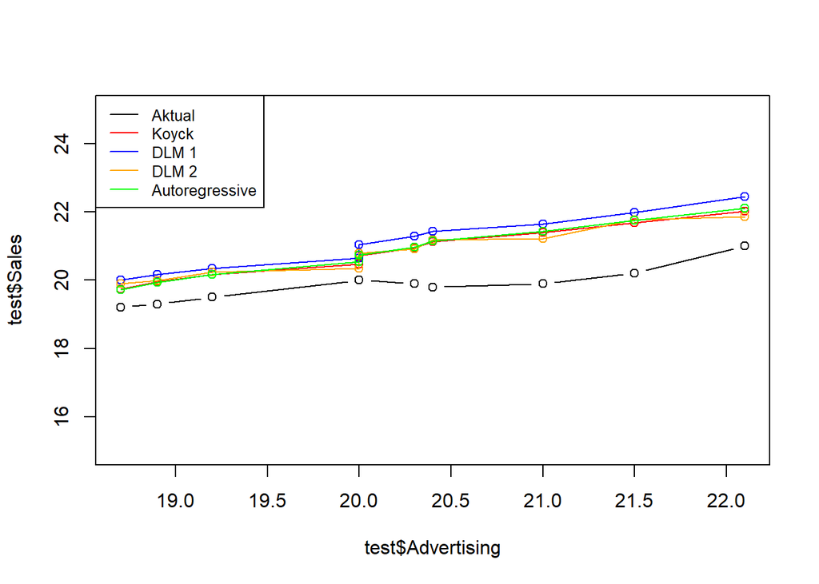

```r
par(mfrow=c(1,1))  # atur layout grafik tunggal

# plot data aktual
plot(test$Advertising, test$Sales, type="b", col="black", ylim=c(15,25))

# tambahkan garis ramalan dari masing-masing model
points(test$Advertising, fore.koyck$forecasts, col="red");   lines(test$Advertising, fore.koyck$forecasts, col="red")
points(test$Advertising, fore.dlm$forecasts, col="blue");    lines(test$Advertising, fore.dlm$forecasts, col="blue")
points(test$Advertising, fore.dlm2$forecasts, col="orange"); lines(test$Advertising, fore.dlm2$forecasts, col="orange")
points(test$Advertising, fore.ardl$forecasts, col="green");  lines(test$Advertising, fore.ardl$forecasts, col="green")

# legenda model
legend("topleft",
       c("Aktual", "Koyck","DLM 1","DLM 2", "Autoregressive"),
       lty=1, col=c("black","red","blue","orange","green"), cex=0.8)
```

# 8 Kesimpulan

Berdasarkan nilai MAPE pada data uji, model dengan nilai MAPE terkecil dianggap sebagai model dengan performa peramalan terbaik untuk data penjualan terhadap biaya iklan ini. Hasil uji asumsi klasik (Durbin-Watson, Breusch-Pagan, dan Shapiro-Wilk) pada model `dynlm` pembanding juga perlu diperhatikan untuk memastikan model yang dipilih memenuhi asumsi regresi yang layak.